# Study note - 第１章

一変量データの記述

Modified

January 9, 2023

## 1 環境構築

- データハンドリングに有用なパッケージ群を積極的に活用する

```r
if(!require("pacman")) {install.packages("pacman")}
pacman::p_load(tidyverse, here, skimr)
```

## 2 1変量データの扱い方

### 2.1 データの読み込み

- クリップボードからの読み込み方法：`scan("Clipboad")`
- 再現性担保のためCSVから機械的に読み込む

```r
# here("Rawdata", "R_book_1") %>% list.files()

math <- readr::read_csv(here("Rawdata", "R_book_1", "Math&Phys.csv")) |>
    dplyr::select(math)
glimpse(math)
```

```
Rows: 146
Columns: 1
$ math <dbl> 90, 65, 60, 75, 50, 60, 25, 35, 85, 100, 45, 95, 80, 80, 95, 55, …
```

### 2.2 ヒストグラムの描写

- bin: 階級
- bin width: 階級の幅
- Number of bin: 階級の数
- frequency: 度数、階級に当てはまるデータの個数
- relative frequency: 全体を１とした場合の割合を示したもの
- `geom_histogram`では相対度数の表現方法が見つからなかったので、マニュアルで計算した
- `hist()`はデフォルトで左半開区間: $a < x \leqq b$
  - `(a, b]`とも表記する

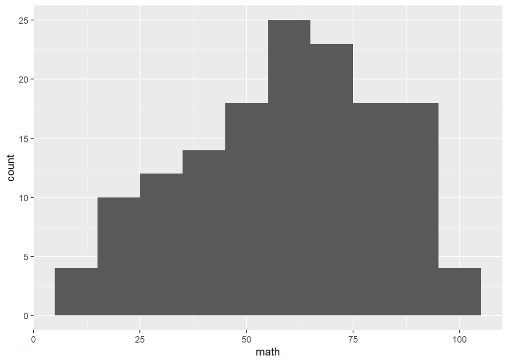

```r
math |>
    ggplot(aes(x = math)) +
    geom_histogram(binwidth = 10)
```

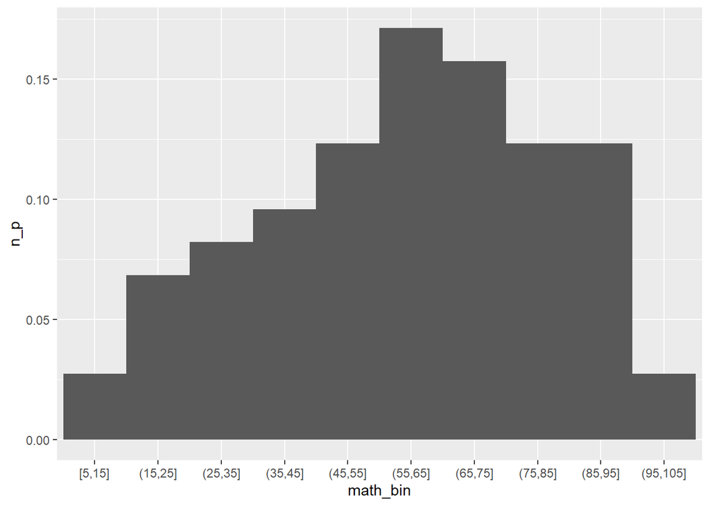

```r
math |>
    dplyr::mutate(math_bin = cut_width(math, width = 10)) |>
    dplyr::group_by(math_bin) |>
    dplyr::summarise(n = n(), .groups = "drop") |>
    dplyr::mutate(n_p = n/sum(n)) |>
    dplyr::arrange(math_bin) |>
    ggplot(aes(x = math_bin,
               y = n_p)) +
    geom_bar(stat = "identity", width = 1)
```

### 2.3 1変数の要約

#### 2.3.1 平均値

##### 2.3.1.1 算術平均 (arithmetic mean)

$$\bar{x} = \frac{1}{n}\sum^{n}_{j=1}x_j$$

```r
mean(math$math)
```

```
[1] 61.60959
```

##### 2.3.1.2 幾何平均 (Geometric mean)

- 増加率の平均など

$$x_G = \sqrt[n]{x_1x_2x_3 \cdots x_n}$$

```r
prod(math$math)^(1/length(math$math))
```

```
[1] 56.42068
```

##### 2.3.1.3 調和平均 (harmonic mean)

- 速度の平均など

$$\frac{1}{x_H} = \frac{1}{n}\sum^{n}_{j=1}\frac{1}{x_j}$$

```r
v <- c(60, 20)
1/mean(1/v)
```

```
[1] 30
```

#### 2.3.2 分散

$$\sigma^2=\frac{1}{n}\sum^{n}_{j=1}(x_j - \bar{x})^2$$

#### 2.3.3 不偏分散

- チルダ(~)は不偏推定量を意味する
- ハット(^)は推定量を意味する

$$\tilde{\sigma^2}=\frac{1}{n-1}\sum^{n}_{j=1}(x_j - \bar{x})^2$$

#### 2.3.4 標準偏差

- 分散の平方根

$$\sigma=\sqrt{\frac{1}{n}\sum^{n}_{j=1}(x_j - \bar{x})^2}$$

- 不偏分散を用いて求めることのほうが多い

$$\sigma=\sqrt{\frac{1}{n-1}\sum^{n}_{j=1}(x_j - \bar{x})^2}$$

```r
# 不偏分散
var(math$math)
```

```
[1] 506.5293
```

```r
# 確認する
epsilon_squad <-
    math |>
    dplyr::mutate(epsilon = math - mean(math)) |>
    dplyr::mutate(epsilon_squad = epsilon^2) |>
    dplyr::pull(epsilon_squad)

sum(epsilon_squad)/(length(epsilon_squad)-1)
```

```
[1] 506.5293
```

```r
# 標準偏差
sd(math$math)
```

```
[1] 22.50621
```

### 2.4 階級数の決め方

- **スタージェスの公式 (Sturges’ rule)**
  - $\lceil$および$\rceil$は天井関数を示す
  - $\lceil x \rceil$は$x$の小数点を切り上げた整数

$$k = \lceil1+\log_2n \rceil$$

```r
# mathデータの場合
1+log(length(math$math), base = 2)
```

```
[1] 8.189825
```

```r
ceiling(1+log(length(math$math), base = 2))
```

```
[1] 9
```

- Rにはその他にも、**スコットの選択法 (Scott’s choice)**、**フリードマン=ダイアコニスの選択法 (Freedman-Diaconis’ choice)** が用意されている

### 2.5 グラフの保存方法

- 省略

### 2.6 分位点と箱ひげ図

- **中央値 (Median)**:データを大きさの順に並べた際の真ん中の値
  - 偶数の場合は真ん中２つの平均値

```r
median(c(56, 78, 81, 90))
```

```
[1] 79.5
```

- **第一四分位点・第三四分位点**: 小さい方から25%、75％の値
- **四分位偏差 (IQR: inter-quantile range)**: Q3-Q1、メディアン付近にどの程度データが集まっているかを示す

#### 2.6.1 箱ひげ図の解釈

```r
math |>
    dplyr::summarise(across(.cols = math,
                            .names = "{.fn}",
                            .fns = list(mean = mean,
                                        min = min,
                                        max = max,
                                        Q1 = ~quantile(.x, 0.25),
                                        Q3 = ~quantile(.x, 0.75)
                            ))) |>
    dplyr::mutate(UpperLim = Q3 + (Q3-Q1)*1.5,
                  LowerLim = Q1 - (Q3-Q1)*1.5)
```

```
# A tibble: 1 × 7
   mean   min   max    Q1    Q3 UpperLim LowerLim
  <dbl> <dbl> <dbl> <dbl> <dbl>    <dbl>    <dbl>
1  61.6    10   100    45    80     132.     -7.5
```

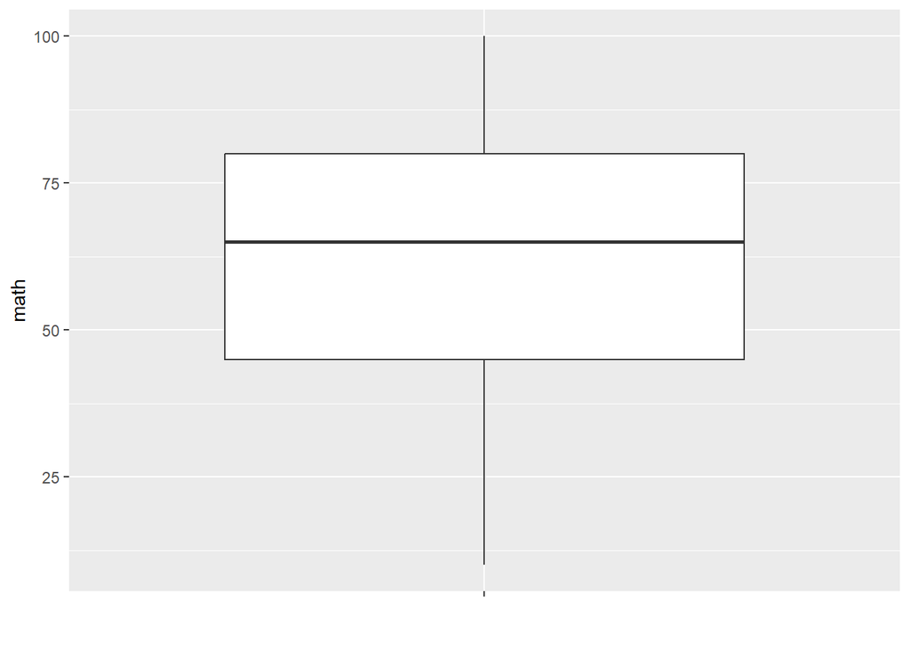

```r
math |>
    ggplot(aes(x = "", y = math)) +
    geom_boxplot() +
    scale_x_discrete(name = "")
```

- ひげの最上位は$Q3+1.5\times IQR$、最下位は$Q1-1.5\times IQR$、データがその範囲にない場合はそれぞれ最大値、最小値が入る
  - そのため、ひげの長さが上下で均等にならない場合がある
- 箱ひげ図の書き方には複数流儀がある
  - 例：高校の数学の教科書では最大値・最小値が入るとしている

### 2.7 外れ値

- Boxplotのひげの外にある点、定義は様々
- 平均値は外れ値に敏感に反応し、中央値は**頑強 (robust)** である

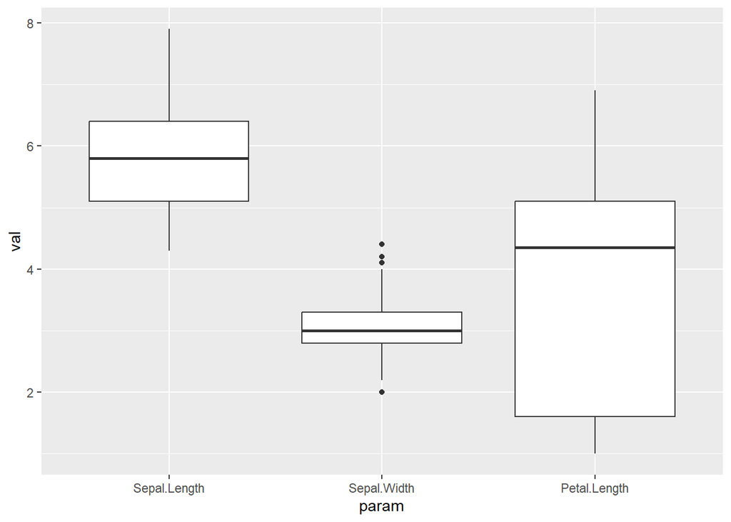

```r
iris |>
    tidyr::pivot_longer(cols = -Species,
                        names_to = "param",
                        values_to = "val") |>
    dplyr::filter(!param %in% c("Petal.Width")) |>
    dplyr::mutate(param = fct_relevel(param, "Sepal.Length", "Sepal.Width")) |>
    ggplot(aes(x = param,
               y = val)) +
    geom_boxplot()
```

### 2.8 最頻値

```r
math |>
    dplyr::pull(math) |>
    table() |>
    which.max() |>
    names()
```

```
[1] "60"
```

### 2.9 欠損値

- Rでは`NA` (Not Available) という記号で表現される
- `NA`に対する四則演算、論理演算はすべて`NA`で返される

```r
# here("Rawdata", "R_book_1") %>% list.files()

math_na <- readr::read_csv(here("Rawdata", "R_book_1", "Not Available.csv")) |>
    dplyr::pull(1)
skimr::skim(math_na)
```

Data summary

| Name | math_na |
| --- | --- |
| Number of rows | 146 |
| Number of columns | 1 |
| _______________________ |  |
| Column type frequency: |  |
| numeric | 1 |
| ________________________ |  |
| Group variables | None |

**Variable type: numeric**

| skim_variable | n_missing | complete_rate | mean | sd | p0 | p25 | p50 | p75 | p100 | hist |
| --- | --- | --- | --- | --- | --- | --- | --- | --- | --- | --- |
| data | 0 | 1 | 61.61 | 22.51 | 10 | 45 | 65 | 80 | 100 | ▂▅▆▇▆ |

```r
math_na2 <- c(NA, math_na)
mean(math_na2)
```

```
[1] NA
```

```r
mean(math_na2, na.rm = TRUE)
```

```
[1] 61.60959
```

## 3 章末問題

### 3.1 1-1

以下より男性の方がばらつきが小さい

```r
# 男性
5.63/171.58*100
```

```
[1] 3.281268
```

```r
# 女性
5.56/158.23*100
```

```
[1] 3.513872
```

### 3.2 1-2

```r
v <- c(2,5,11,7,9)

# 平均
mean(v)
```

```
[1] 6.8
```

```r
#　幾何平均
prod(v)^(1/length(v))
```

```
[1] 5.863361
```

```r
# 調和平均
1/mean(1/v)
```

```
[1] 4.785251
```

```r
# 不偏分散
var(v)
```

```
[1] 12.2
```

```r
# 不偏分散の平方根
sqrt(var(v))
```

```
[1] 3.49285
```

### 3.3 1-3

```r
v <- c(34,56,32,15,49)

# 平均偏差
abs(v - mean(v)) |> sum()/length(v)
```

```
[1] 12.24
```

```r
# 標準偏差
sd(v)
```

```
[1] 15.99062
```

### 3.4 1-4

```r
score <- c(65, 59, 62)
num <- c(500, 750, 690)

sum(score*num)/sum(num)
```

```
[1] 61.6134
```

### 3.5 1-5

```r
height <- c(171.8, 167.2, 180.9)
weight <- c(74.4,  56.3,  93.2)

weight/((height/100)^2)
```

```
[1] 25.20732 20.13890 28.47992
```

### 3.6 1-6

```r
v <- c(3,4,8,11,7)

# 不偏分散の平方根≒不偏標準偏差
var(v) |> sqrt()
```

```
[1] 3.209361
```

```r
# 標準偏差
sqrt( var(v)*(length(v)-1) / length(v) )
```

```
[1] 2.87054
```

### 3.7 1-7

```r
sigma <- sd(math$math)
mu <- mean(math$math)

# 40
50+((40-mu)/sigma)*10
```

```
[1] 40.39839
```

```r
# 85
50+((85-mu)/sigma)*10
```

```
[1] 60.39287
```

### 3.8 1-8

```r
set.seed(54147)

x <- rnorm(n = 100, mean = 50, sd = 10)
1+log(length(x), base = 2)
```

```
[1] 7.643856
```

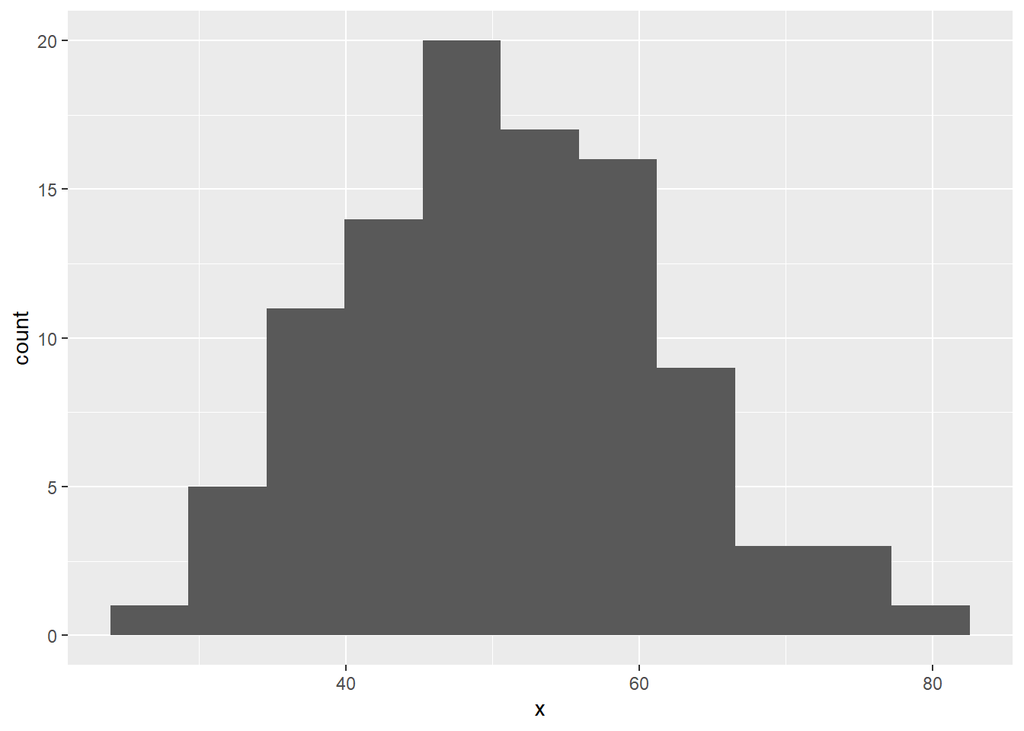

```r
ggplot(data = NULL,
       aes(x = x)) +
    geom_histogram(bins = 11)
```

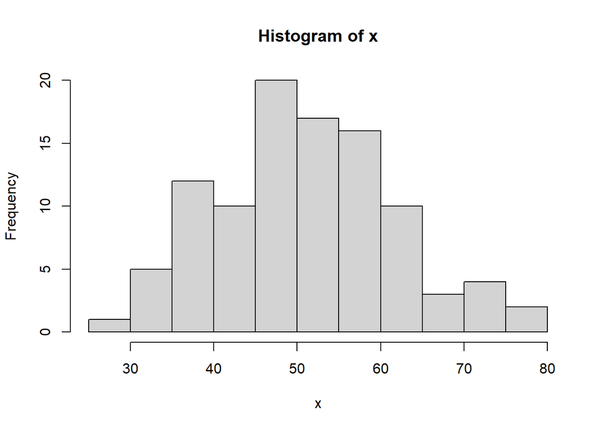

```r
hist(x)
```

### 3.9 1-9

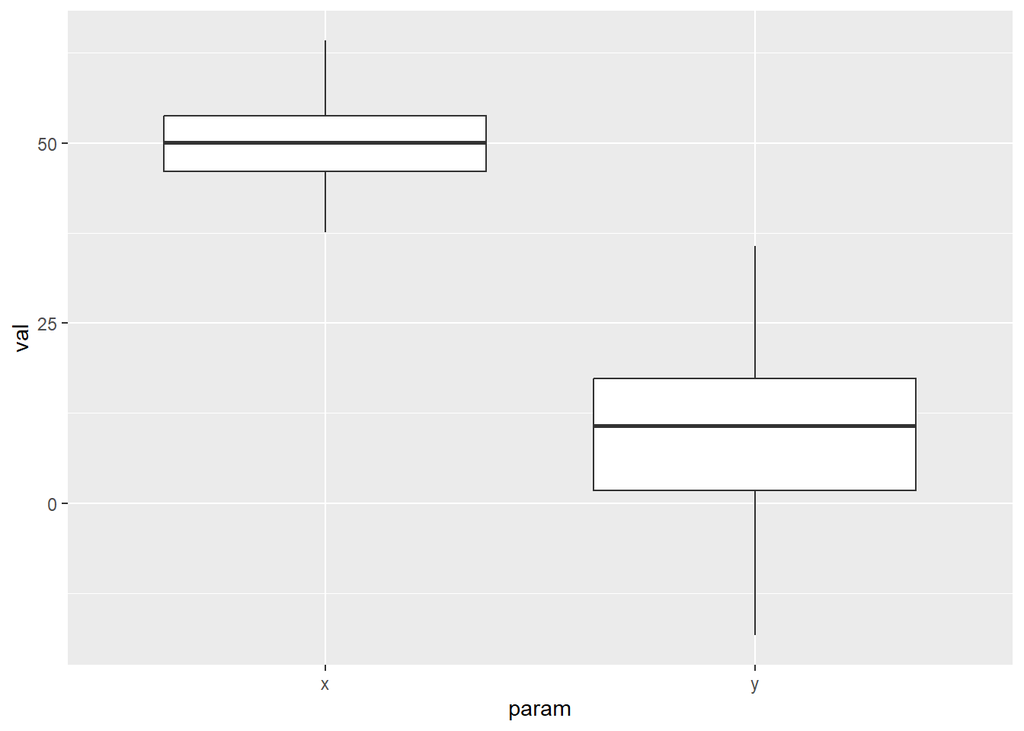

```r
set.seed(54147)

x <- rnorm(n = 100, mean = 50, sd = 5)
y <- rnorm(n = 100, mean = 10, sd = 10)

tibble(x = x,
       y = y) |>
    tidyr::pivot_longer(cols = everything(),
                        names_to = "param",
                        values_to = "val") |>
    ggplot(aes(x = param, y = val)) +
    geom_boxplot()
```

```r
tibble(x = x,
       y = y) |>
    tidyr::pivot_longer(cols = everything(),
                        names_to = "param",
                        values_to = "val") |>
    dplyr::group_by(param) |>
    dplyr::summarise(across(.cols = val,
                            .fns = list(Q1 = ~quantile(.x, 0.25),
                                        Q3 = ~quantile(.x, 0.75)),
                            .names = "{.fn}")) |>
    dplyr::mutate(IQR = Q3 - Q1)
```

```
# A tibble: 2 × 4
  param    Q1    Q3   IQR
  <chr> <dbl> <dbl> <dbl>
1 x     46.0   53.7  7.72
2 y      1.81  17.4 15.5
```

### 3.10 1-10

```r
x <- rnorm(n = 5, mean = 170, sd = 10)
y <- c(500, x)

str_c("mean: ",
      mean(y) |> round(digits = 1),
      ", median: ",
      median(y)|> round(digits = 1)
      )
```

```
[1] "mean: 225.6, median: 173.5"
```

### 3.11 1-11

```r
str_c("x, mad: ",
      mad(x) |> round(digits = 1),
      ", sd: ",
      sd(x) |> round(digits = 1))
```

```
[1] "x, mad: 3.1, sd: 5.6"
```

```r
str_c("y, mad: ",
      mad(y) |> round(digits = 1),
      ", sd: ",
      sd(y) |> round(digits = 1))
```

```
[1] "y, mad: 3.7, sd: 134.5"
```

### 3.12 1-12

```r
# skweness
mean( scale(math$math, center = TRUE, scale = TRUE)^3 )
```

```
[1] -0.2721035
```

```r
# mean( scale(rnorm(n = 50000, mean = 0, sd = 1), center = TRUE, scale = TRUE)^3 )

# kurtosis
mean( scale(math$math, center = TRUE, scale = TRUE)^4)-3
```

```
[1] -0.8259503
```

```r
# mean( scale(rnorm(n = 500, mean = 0, sd = 1), center = TRUE, scale = TRUE)^4)-3
```

### 3.13 1-13

- 数式を展開する
  - 平均値の２乗の平均がトリッキー

$$\begin{equation}
\begin{split}
\sigma^2 &= \frac{1}{n}\sum^n_{j = 1}(x_j - \bar{x})^2 \\
&= \frac{1}{n}\sum^n_{j = 1}x_j^2 - 2\bar{x} \frac{1}{n}\sum^n_{j = 1} x_j + \frac{1}{n}\sum^n_{j = 1}\bar{x}^2 \\
&= \bar{x_j^2} - 2\bar{x}^2 + \bar{x}^2\\
&= \bar{x_j^2} - \bar{x}^2
\end{split}
\end{equation}$$

### 3.14 1-14

展開する

$$\begin{equation}\begin{split}
f(a) &= \sum^n_{j=1}(x_j - a)^2 \\
&= \sum^n_{j=1}x_j^2 - \sum^n_{j=1}2ax_j + \sum^n_{j=1}a^2
\end{split}\end{equation}$$

$a$の下凸な２次関数であるから、導関数=0となるようにすればよい

$$\begin{equation}\begin{split}
f'(a) &= -\sum^n_{j=1}2x_j + \sum^n_{j=1}2a \\
&= 2\sum^n_{j=1}a - x_j
\end{split}\end{equation}$$

$$\begin{equation}\begin{split}
2\sum^n_{j=1}a - x_j &= 0 \\
2na &= 2\sum^n_{j=1}x_j \\
a &= \frac{1}{n}\sum^n_{j=1}x_j
\end{split}\end{equation}$$

よって、平均値は残差平方和を最小とする